# Análisis del 10% de mayores ingresos en Chile

Marcos González, Agustín Rabie

26 January, 2025

## Abstract

Este estudio analiza los determinantes de la pertenencia al 10% superior de ingresos en Chile utilizando técnicas de machine learning. Mediante el uso combinado de las encuestas CASEN 2020 y EBS 2021, desarrollamos un modelo predictivo que identifica las características socioeconómicas, demográficas y de bienestar subjetivo asociadas a la pertenencia a este grupo. El análisis contribuye a la literatura sobre élites económicas en Chile, aportando evidencia sobre los mecanismos de reproducción de la desigualdad económica.

La literatura internacional muestra que el 10% de mayores ingresos presenta características sociodemográficas distintivas que tienen profundas implicaciones para la cohesión social y las políticas públicas: Influencia Política (Gilens, 2012); impacto en Desigualdad y Bienestar (Wilkinson & Pickett, 2010; 2019); Segregación Social (Méndez & Gayo, 2024; Hernando & Mitchell, 2023). En ese contexto, un modelo predictivo de Machine Learning permitirá: - Validar si los patrones internacionales se replican en Chile - Identificar variables no teorizadas previamente

## Objetivos

### Objetivo General

Desarrollar y evaluar un modelo de machine learning para predecir la pertenencia al 10% superior de ingresos en Chile utilizando datos socioeconómicos y de bienestar.

### Objetivos Específicos

- Identificar un conjunto de variables capaces de predecir la pertenencia al 10% superior de ingresos
- Examinar la distribución espacial y las características socioeconómicas del 10% superior de ingresos
- Evaluar el desempeño predictivo de diferentes algoritmos de machine learning
- Analizar la importancia relativa de las variables en la predicción

## Preparación y descripción de los datos

Para comenzar el análisis, se cargan las bibliotecas necesarias y se establecen los parámetros de configuración. Se utiliza una combinación de paquetes para manipulación de datos (haven, dplyr, tidyr, purrr, magrittr, stringr), visualización (ggplot2, scales, viridis, DiagrammeR), manejo de datos espaciales (sf, geodata, chilemapas, rmapshaper) y presentación de resultados (kableExtra), presentación (kableExtra, webshot2, naniar) y utilidades (devtools, rlang). Se documentan también versiones de paquetes críticos.

## Carga y preparación inicial de datos

El análisis utiliza dos fuentes principales de datos:

CASEN 2020 (versión reducida, en formato rds para poder subirse a GitHub): Proporciona información socioeconómica detallada EBS 2021: Complementa con información adicional (especialmente de bienestar) y factores de expansión actualizados

En el proceso de preparación, se realizan los siguientes pasos: a. Cálculo de deciles de ingreso para identificar el 10% superior según la muestra total de la encuesta CASEN, no de la submuestra de la EBS. b. Creación de variable binaria para el grupo objetivo. c. Merge de ambas bases de datos manteniendo la estructura de la CASEN.

```r
casen <- readRDS(ruta_casen)
ebs <- read_sav(ruta_ebs)

# Calcular deciles y crear variable top10 en CASEN
casen <- casen %>%
  mutate(
    decil = ntile(ytotcorh, 10),
    top10 = ifelse(decil == 10, 1, 0)
  ) %>%
  rename(
    folio_casen = folio,
    id_persona_casen = id_persona
  )

# Realizar el merge manteniendo todas las variables
merged_data <- merge(
  casen,
  ebs %>% select(
    folio_casen, id_persona_casen, fexp, region,
    j3a_1, j3a_4, a3_4, j3a_5,  # Variables de bienestar laboral
    c1_4, c1_5, c3_2, c6,        # Variables de uso del tiempo
    l8, l9, l10a, l10b         # Variables para identificar situación laboral
  ),
  by = c("folio_casen", "id_persona_casen"),
  suffixes = c("_casen", "_ebs")  # Para diferenciar variables duplicadas
) %>%
  mutate(
    elite = ifelse(decil == 10, 1, 0),
    elite_label = factor(ifelse(decil == 10, "10% superior", "Resto"))
  )
```

La tabla de resumen del proceso de merge que aparece en el documento muestra que:

- CASEN original tiene 185,437 observaciones: Presenta sólo 98 NAs en la variable ytotcorh de ingreso del hogar corregido, lo cual es marginal. También debe considerarse que estamos tomando al hogar como unidad y no a individuos (y los individuos que responden la encuesta pueden no corresponder a los/las jefes/as de hogar).
- EBS y la base final fusionada tienen 10,921 observaciones (debe considerarse también que quienes responden no necesariamente con la misma persona que en el caso de CASEN, a pesar de ser el mismo hogar).

Esto implica una retención del 5.9% de la muestra original de CASEN, lo cual es esperable dado que la EBS es una submuestra de CASEN. Lo crucial aquí es verificar que esta submuestra mantiene representatividad, especialmente para el grupo de interés (10% superior).

### Representatividad y factores de expansión:

Del análisis de los factores de expansión se observa:

- El 10% superior representa 1,859,535 personas en la población.
- El resto representa 13,304,855 personas.
- La razón de expansión promedio es mayor para el grupo elite (1,909 vs 1,337).

```r
# Análisis de datos antes del merge
n_casen_original <- nrow(casen)
n_ebs_original <- nrow(ebs)

# Análisis después del merge
n_merged <- nrow(merged_data)

merge_summary <- data.frame(
  etapa = c("CASEN original", "EBS original", "Después del merge"),
  n_observaciones = c(n_casen_original, n_ebs_original, n_merged)
) %>%
  mutate(
    perdida_registros = c(NA, NA, n_casen_original - n_merged),
    porcentaje_retencion = c(NA, NA, round(n_merged/n_casen_original * 100, 1))
  )

kable(merge_summary,
      caption = "Resumen del proceso de merge CASEN-EBS",
      col.names = c("Etapa", "N observaciones", "Pérdida de registros", "% retención")) %>%
  kable_styling(bootstrap_options = c("striped", "hover"))
```

Resumen del proceso de merge CASEN-EBS

| Etapa | N observaciones | Pérdida de registros | % retención |
| --- | --- | --- | --- |
| CASEN original | 185437 | NA | NA |
| EBS original | 10921 | NA | NA |
| Después del merge | 10921 | 174516 | 5.9 |

```r
# Análisis de deciles antes y después del merge
deciles_comparison <- casen %>%
  group_by(decil) %>%
  summarise(n_casen = n()) %>%
  left_join(
    merged_data %>%
      group_by(decil) %>%
      summarise(n_merged = n()),
    by = "decil"
  ) %>%
  mutate(
    prop_retencion = round(n_merged/n_casen * 100, 1)
  )

kable(deciles_comparison,
      caption = "Retención de observaciones por decil después del merge",
      col.names = c("Decil", "N en CASEN", "N después del merge", "% retención")) %>%
  kable_styling(bootstrap_options = c("striped", "hover"))
```

Retención de observaciones por decil después del merge

| Decil | N en CASEN | N después del merge | % retención |
| --- | --- | --- | --- |
| 1 | 18534 | 1117 | 6.0 |
| 2 | 18534 | 1204 | 6.5 |
| 3 | 18534 | 1099 | 5.9 |
| 4 | 18534 | 1093 | 5.9 |
| 5 | 18534 | 1096 | 5.9 |
| 6 | 18534 | 1082 | 5.8 |
| 7 | 18534 | 1100 | 5.9 |
| 8 | 18534 | 1104 | 6.0 |
| 9 | 18534 | 1052 | 5.7 |
| 10 | 18533 | 974 | 5.3 |
| NA | 98 | NA | NA |

Los 974 casos que pertenecen al 10% superior representan aproximadamente el 9% de nuestra muestra, lo cual es consistente con la distribución poblacional esperada. Esto nos proporciona una base sólida para el modelamiento:

- La proporción 9%-91% (vs un 10%-90% ideal) representa un desbalance moderado.
- Es manejable con ponderación de clases en Random Forest.
- No requiere submuestreo de la clase mayoritaria.

Rothman y Greenland (2018) argumentan que es más apropiado planificar el tamaño del estudio basándose en la precisión deseada rather que en el poder estadístico tradicional. En nuestro caso, con 974 casos de 10,921 observaciones, alcanzamos una precisión adecuada.

En términos del tamaño muestral requerido para el análisis predictivo, considerando aproximadamente 45 predictores candidatos (6-1[dummy] en bienestar, 9-1 en tenencia, 5-1 en nivel educacional, 12-1 intervalos de edad, 16-1 en Región, más zona y sexo), los 974 eventos nos proporcionan 21.6 eventos por variable, superando los umbrales mínimos estándar en la literatura de predicción. Si bien este criterio es simplificador (van Smeden et al., 2019), proporciona una base razonable para proceder con el análisis predictivo propuesto.

## Modelo Entidad-Relación

El diagrama presentado muestra la estructura de los datos, que se organiza en cuatro entidades principales:

- REGIÓN {id_region}: Permite el análisis territorial de la distribución del ingreso.
- HOGAR {folio_casen} Unidad fundamental de análisis económico.
- INDIVIDUO {id_persona_casen} Unidad básica de observación.
- CARACTERÍSTICAS: Atributos del individuo (sea o no jefe/a de hogar).

```r
DiagrammeR::grViz("
  digraph ER {
    # Configuración general del gráfico
    graph [rankdir = TB,
           fontname = 'Helvetica',
           nodesep = 0.4,
           ranksep = 0.6]

    # Configuración de nodos
    node [shape = rectangle,
          style = filled,
          fillcolor = lightblue,
          fontname = 'Helvetica',
          fontsize = 10,
          width = 2,
          height = 0.5]

    # Configuración de bordes
    edge [fontname = 'Helvetica',
          fontsize = 8,
          len = 1.2]

    # Entidades principales
    region [label = 'REGIÓN\n{id_region}\n(nombre)', width = 2]
    hogar [label = 'HOGAR\n{folio_casen}\n(ingresos_totales, n_integrantes,\ntipo_vivienda, tenencia)', width = 3]
    individuo [label = 'INDIVIDUO\n{id_persona_casen}\n(edad, sexo, elite)', width = 2.5]

    # Atributos como subentidades
    educacion [label = 'CARACTERÍSTICAS EDUCATIVAS\n(nivel, años)', width = 2.5]
    trabajo [label = 'CARACTERÍSTICAS LABORALES\n(ocupación, categoría, cotización)', width = 2.5]
    bienestar [label = 'BIENESTAR\n(uso tiempo, satisfacción)', width = 2.5]

    # Relaciones
    region -> hogar [label = 'contiene']
    hogar -> individuo [label = 'compuesto por']

    # Relaciones con atributos
    individuo -> educacion [label = 'tiene']
    individuo -> trabajo [label = 'tiene']
    individuo -> bienestar [label = 'tiene']

    # Alineación y espaciado
    {rank = same; educacion; trabajo; bienestar}

    # Nota explicativa
    nota [label = 'Variable objetivo:\nelite (1: pertenece al 10% superior, 0: resto)',
          shape = note,
          fillcolor = lightyellow,
          width = 3]
    nota -> hogar [style = dashed]
  }
",
width = 800, height = 500)
```

[interactive chart not shown]

## Análisis descriptivo inicial

Examinación de valores faltantes El gráfico de patrones de valores faltantes nos muestra una estructura importante:

- Variables sin datos faltantes (0% missing): Variables sociodemográficas básicas (edad, sexo, zona, región) Variables económicas (ytotcorh, elite, fexp) Variables educativas (e6a) Variables de vivienda (v13)
- Variables con alta tasa de missing (~42%): Variables de bienestar laboral (j3a_1, j3a_4, j3a_5): 4,606 casos missing Variables de uso del tiempo (a3_4, c3_2, c6): 4,606 casos missing
- Variables con tasa media de missing (~35%): Tenencia de vivienda (v13_propia): 3,805 casos missing

Esto sugiere: Las variables socioeconómicas básicas están completas. Hay un patrón sistemático de no respuesta en variables de bienestar. La pérdida de información en variables de bienestar afecta aproximadamente al 42% de la muestra.

```r
stats_deciles <- merged_data %>%
  group_by(decil) %>%
  summarise(
    n = n(),
    n_expandido = sum(fexp),
    ingreso_medio = weighted.mean(ytotcorh, fexp, na.rm = TRUE),
    proporcion_poblacion = sum(fexp)/sum(merged_data$fexp)
  )

vars_of_interest <- c(
  # Variables sociodemográficas básicas (verificadas en el merge)
  "edad", "sexo", "zona", "region",

  # Variables educativas y de vivienda
  "e6a", "v13", "v13_propia",

  # Variables económicas
  "ytotcorh", "elite", "fexp",

  # Variables de bienestar de EBS
  "j3a_1", "j3a_4", "a3_4", "j3a_5",
  "c1_4", "c1_5", "c3_2", "c6"
)

existing_vars <- names(merged_data)
vars_of_interest <- vars_of_interest[vars_of_interest %in% existing_vars]

# visualización de patrones de valores faltantes
gg_miss_var(merged_data[vars_of_interest]) +
  theme_minimal() +
  theme(
    axis.text.y = element_text(size = 9),
    plot.title = element_text(size = 12, face = "bold"),
    panel.grid.major.x = element_line(color = "grey90"),
    panel.grid.minor.x = element_blank()
  ) +
  labs(
    title = "Patrón de valores faltantes en variables principales",
    subtitle = "Se muestran todas las variables relevantes para el modelo",
    x = "Número de valores faltantes",
    y = "Variables"
  )
```

[figure not shown]

```r
# Tabla resumen de valores faltantes
missing_summary <- merged_data[vars_of_interest] %>%
  summarise(across(everything(),
                  list(
                    n_missing = ~sum(is.na(.)),
                    pct_missing = ~mean(is.na(.)) * 100
                  ))) %>%
  pivot_longer(everything(),
               names_to = c("variable", "stat"),
               names_pattern = "(.*)_(n_missing|pct_missing)") %>%
  pivot_wider(names_from = stat,
             values_from = value) %>%
  mutate(
    total_obs = nrow(merged_data),
    obs_available = total_obs - n_missing,
    pct_missing = round(pct_missing, 2)
  ) %>%
  arrange(desc(pct_missing))

kable(missing_summary,
      col.names = c("Variable", "N Missing", "% Missing", "Total Obs", "Obs Disponibles"),
      caption = "Resumen detallado de valores faltantes por variable") %>%
  kable_styling(bootstrap_options = c("striped", "hover", "condensed")) %>%
  row_spec(which(missing_summary$pct_missing > 20),
          background = "#FFE5E5")  # Resaltar variables con más del 20% de valores faltantes
```

Resumen detallado de valores faltantes por variable

| Variable | N Missing | % Missing | Total Obs | Obs Disponibles |
| --- | --- | --- | --- | --- |
| j3a_1 | 4606 | 42.18 | 10921 | 6315 |
| j3a_4 | 4606 | 42.18 | 10921 | 6315 |
| a3_4 | 4606 | 42.18 | 10921 | 6315 |
| j3a_5 | 4606 | 42.18 | 10921 | 6315 |
| c3_2 | 4606 | 42.18 | 10921 | 6315 |
| c6 | 4606 | 42.18 | 10921 | 6315 |
| v13_propia | 3805 | 34.84 | 10921 | 7116 |
| edad | 0 | 0.00 | 10921 | 10921 |
| sexo | 0 | 0.00 | 10921 | 10921 |
| zona | 0 | 0.00 | 10921 | 10921 |
| region | 0 | 0.00 | 10921 | 10921 |
| e6a | 0 | 0.00 | 10921 | 10921 |
| v13 | 0 | 0.00 | 10921 | 10921 |
| ytotcorh | 0 | 0.00 | 10921 | 10921 |
| elite | 0 | 0.00 | 10921 | 10921 |
| fexp | 0 | 0.00 | 10921 | 10921 |
| c1_4 | 0 | 0.00 | 10921 | 10921 |
| c1_5 | 0 | 0.00 | 10921 | 10921 |

## Visualización de la distribución por deciles

El gráfico de ingresos promedio por decil muestra una marcada desigualdad. El décimo decil (en rojo) tiene un ingreso promedio de más de 4 millones de pesos. La diferencia con el noveno decil es especialmente notoria, pues el 10% superior captura 40.5% del ingreso total.

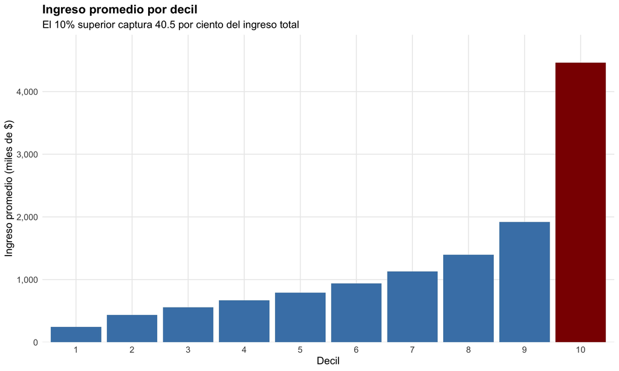

## Caracterización del 10% superior vs resto de la población

La tabla siguiente compara características clave entre este grupo y el resto de la población. Se incluyen variables territoriales (región, urbano/rural), demográficas (edad, sexo), socioeconómicas (educación) y de bienestar. Los valores están ponderados usando los factores de expansión provistos por la EBS: seleccionamos éstos en vez de los de CASEN por tratarse de una encuesta bifásica.

```r
# Variable dummy para el 10% superior
merged_data <- merged_data %>%
  mutate(
    elite = ifelse(decil == 10, 1, 0),
    elite_label = factor(ifelse(decil == 10, "10% superior", "Resto"))
  )

# Análisis descriptivo por grupo
stats_descriptivos <- merged_data %>%
  group_by(elite_label) %>%
  summarise(
    n = n(),
    n_expandido = sum(fexp),
    ingreso_promedio = round(weighted.mean(ytotcorh, fexp, na.rm = TRUE)),
    desv_est = round(sqrt(weighted.mean((ytotcorh - weighted.mean(ytotcorh, fexp))^2, fexp))),
    edad_promedio = weighted.mean(edad, fexp, na.rm = TRUE),
    prop_hombres = weighted.mean(sexo == 1, fexp, na.rm = TRUE),
    prop_urbano = weighted.mean(zona == 1, fexp, na.rm = TRUE)
  ) %>%
  mutate(
    prop_muestra = n/sum(n),
    prop_poblacion = n_expandido/sum(n_expandido)
  )

stats_descriptivos %>%
  kbl(caption = "Características del 10% superior vs resto",
      digits = 2,
      format.args = list(big.mark = ",")) %>%
  kable_styling(bootstrap_options = c("striped", "hover"))
```

Características del 10% superior vs resto

| elite_label | n | n_expandido | ingreso_promedio | desv_est | edad_promedio | prop_hombres | prop_urbano | prop_muestra | prop_poblacion |
| --- | --- | --- | --- | --- | --- | --- | --- | --- | --- |
| 10% superior | 974 | 1,859,535 | 4,460,648 | 2,993,049 | 41.27 | 0.56 | 0.95 | 0.09 | 0.12 |
| Resto | 9,947 | 13,304,855 | 917,774 | 500,956 | 44.87 | 0.48 | 0.87 | 0.91 | 0.88 |

## Análisis territorial

El análisis territorial se desarrolla en dos dimensiones complementarias:

Proporción interna: Qué porcentaje de la población de cada región pertenece al 10% superior Distribución nacional: Cómo se distribuye el total del 10% superior entre las regiones

Para facilitar la interpretación, se ordenan las regiones de norte a sur.

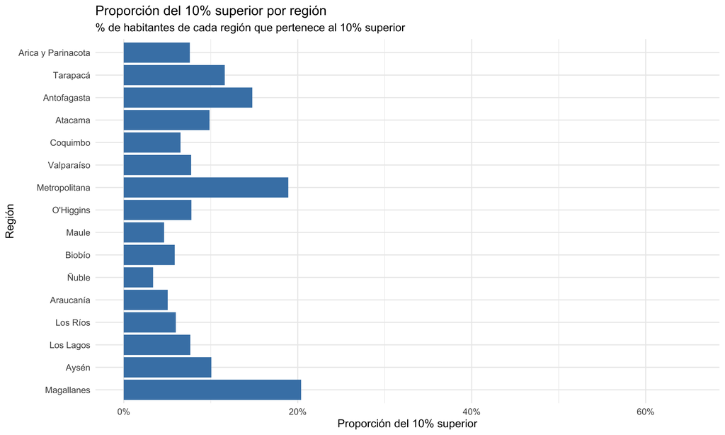

```r
# Nombres de regiones ordenadas de norte a sur
nombres_regiones <- c(
  "15" = "Arica y Parinacota",
  "1" = "Tarapacá",
  "2" = "Antofagasta",
  "3" = "Atacama",
  "4" = "Coquimbo",
  "5" = "Valparaíso",
  "13" = "Metropolitana",
  "6" = "O'Higgins",
  "7" = "Maule",
  "8" = "Biobío",
  "16" = "Ñuble",
  "9" = "Araucanía",
  "14" = "Los Ríos",
  "10" = "Los Lagos",
  "11" = "Aysén",
  "12" = "Magallanes"
)

merged_data <- merged_data %>%
  mutate(
    region_nombre = factor(region,
                          levels = rev(c("15", "1", "2", "3", "4", "5", "13", "6",
                                   "7", "8", "16", "9", "14", "10", "11", "12")),
                          labels = rev(nombres_regiones[c("15", "1", "2", "3", "4", "5", "13", "6",
                                                    "7", "8", "16", "9", "14", "10", "11", "12")]),
                          ordered = TRUE)
  )

# Stats_region para el primer gráfico
stats_region <- merged_data %>%
  group_by(region_nombre) %>%
  summarise(
    n = n(),
    prop_elite = weighted.mean(elite, fexp, na.rm = TRUE),
    ingreso_medio = weighted.mean(ytotcorh, fexp, na.rm = TRUE)
  )

# Distribución del 10% superior entre regiones
stats_distribucion <- merged_data %>%
  group_by(region_nombre) %>%
  summarise(
    n_elite = sum(elite * fexp),  # Número ponderado de elite en cada región
    n_total = sum(fexp)          # Población total ponderada
  ) %>%
  ungroup() %>%
  mutate(
    prop_distribucion = n_elite / sum(n_elite)  # Proporción del total de elite
  )

max_prop <- max(c(
  stats_region$prop_elite,
  stats_distribucion$prop_distribucion
))

# Gráfico de barras 1
p1 <- ggplot(stats_region,
       aes(x = region_nombre,
           y = prop_elite)) +
  geom_bar(stat = "identity", fill = "steelblue") +
  coord_flip() +
  scale_y_continuous(
    labels = scales::percent,
    limits = c(0, max_prop)  # Usar el mismo límite
  ) +
  labs(
    title = "Proporción del 10% superior por región",
    subtitle = "% de habitantes de cada región que pertenece al 10% superior",
    x = "Región",
    y = "Proporción del 10% superior"
  ) +
  theme_minimal()

# Gráfico de barras 2
p2 <- ggplot(stats_distribucion,
       aes(x = region_nombre,
           y = prop_distribucion)) +
  geom_bar(stat = "identity", fill = "darkred") +
  coord_flip() +
  scale_y_continuous(
    labels = scales::percent,
    limits = c(0, max_prop)  # Usar el mismo límite
  ) +
  labs(
    title = "Distribución regional del 10% superior",
    subtitle = "Cómo se distribuye el 10% superior entre las regiones",
    x = "Región",
    y = "% del total del 10% superior"
  ) +
  theme_minimal()

p1
```

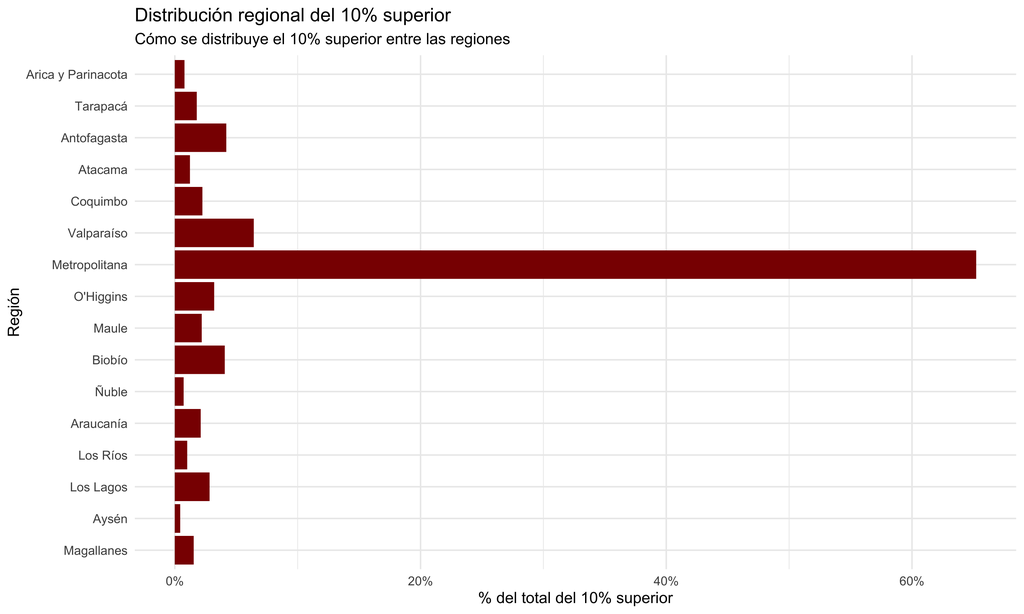

```r
p2
```

Los gráficos resultantes revelan patrones interesantes. La proporción de elite dentro de cada región (gráfico azul) muestra una concentración en ciertas regiones (Magallanes, RM, Antofagasta,) La distribución del total de la elite (gráfico rojo) evidencia una fuerte centralización en RM.

## Visualización espacial

Aquí generamos mapas que permiten una visualización más intuitiva de los patrones espaciales. Se utilizan dos mapas que corresponden a las mismas dimensiones analizadas en los gráficos de barras:

El primer mapa muestra la proporción de habitantes de cada región que pertenece al 10% superior. Este mapa ayuda a identificar dónde es más probable encontrar miembros de la elite económica. El segundo mapa (en tonos magma) visualiza cómo se distribuye el total de ese 10% entre las regiones.

Para la construcción de estos mapas, se enfrentaron varios desafíos técnicos: La necesidad de compatibilizar diferentes codificaciones de regiones: Magallanes tenía problemas de visualización que lo convertía persistentemente en NA.

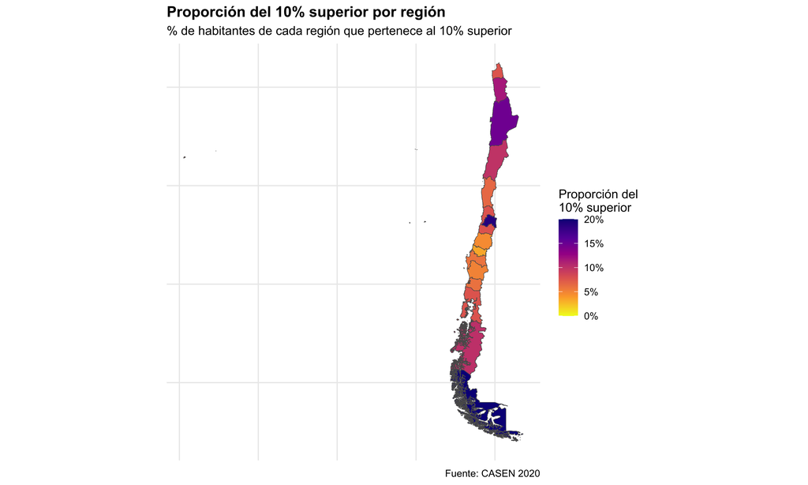

```r
# Datos para el primer mapa (proporción dentro de cada región)
datos_mapa1 <- merged_data %>%
  group_by(region) %>%
  summarise(prop_elite = weighted.mean(elite, fexp, na.rm = TRUE)) %>%
  mutate(region = as.character(region))

# Datos para el segundo mapa (distribución entre regiones)
datos_mapa2 <- merged_data %>%
  group_by(region) %>%
  summarise(
    n_elite = sum(elite * fexp),
    n_total = sum(fexp)
  ) %>%
  ungroup() %>%
  mutate(
    region = as.character(region),
    prop_distribucion = n_elite / sum(n_elite)
  )

# Obtener mapa de Chile y asignar valores
chile_map <- geodata::gadm("CHL", level = 1, path = tempdir())
mapa_base <- st_as_sf(chile_map)

codigo_region <- c(
  "XV" = "15", "I" = "1", "II" = "2", "III" = "3", "IV" = "4",
  "V" = "5", "RM" = "13", "VI" = "6", "VII" = "7", "VIII" = "8",
  "XVI" = "16", "IX" = "9", "XIV" = "14", "X" = "10", "XI" = "11",
  "XII" = "12"
)

# Preparar base para ambos mapas
mapa_base$region <- codigo_region[mapa_base$CC_1]
mapa1 <- left_join(mapa_base, datos_mapa1, by = "region")
mapa2 <- left_join(mapa_base, datos_mapa2, by = "region")

# Primer mapa (proporción dentro de cada región)
m1 <- ggplot() +
  geom_sf(data = mapa1,
          aes(fill = prop_elite),
          na.rm = TRUE) +
  scale_fill_viridis_c(
    labels = scales::percent,
    name = "Proporción del\n10% superior",
    option = "plasma",
    direction = -1,
    na.value = "grey50",
    limits = c(0, 0.20),
    oob = scales::squish
  ) +
  labs(
    title = "Proporción del 10% superior por región",
    subtitle = "% de habitantes de cada región que pertenece al 10% superior",
    caption = "Fuente: CASEN 2020"
  ) +
  theme_minimal() +
  theme(
    plot.title = element_text(face = "bold"),
    axis.text = element_blank(),
    axis.ticks = element_blank()
  )

# Segundo mapa (distribución entre regiones)
m2 <- ggplot() +
  geom_sf(data = mapa2,
          aes(fill = prop_distribucion),
          na.rm = TRUE) +
  scale_fill_viridis_c(
    labels = scales::percent,
    name = "% del total del\n10% superior",
    option = "magma",  # Cambié a magma para distinguirlo del otro mapa
    direction = -1,
    na.value = "grey50",
    oob = scales::squish
  ) +
  labs(
    title = "Distribución regional del 10% superior",
    subtitle = "Cómo se distribuye el 10% superior entre las regiones",
    caption = "Fuente: CASEN 2020"
  ) +
  theme_minimal() +
  theme(
    plot.title = element_text(face = "bold"),
    axis.text = element_blank(),
    axis.ticks = element_blank()
  )

m1
```

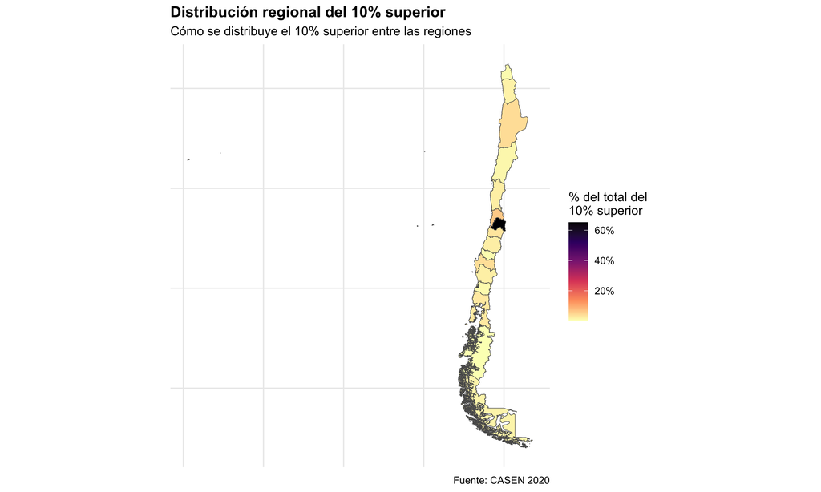

```r
m2
```

## Sexo jefe/a de hogar

Distribución y proporción de elite por sexo del jefe de hogar

| Sexo | N | N expandido | Proporción elite | Proporción muestra | Proporción población |
| --- | --- | --- | --- | --- | --- |
| Mujer | 2710 | 3129383 | 6.2% | 0.525 | 0.454 |
| Hombre | 2454 | 3757075 | 14.1% | 0.475 | 0.546 |

Observaciones importantes: - Los hogares con jefatura masculina tienen más del doble de probabilidad de pertenecer al 10% superior. - Hay una discrepancia entre proporción muestral y poblacional que sugiere sobremuestreo de - hogares con jefatura femenina. - La proporción de elite es notablemente menor en hogares con jefatura femenina.

```r
# Etiquetas de parentesco
etiquetas_parentesco <- c(
  "1" = "Jefe(a) de Hogar",
  "2" = "Esposo(a) o pareja de distinto sexo",
  "3" = "Esposo(a) o pareja de igual sexo",
  "4" = "Hijo(a) de ambos",
  "5" = "Hijo(a) sólo del jefe(a)",
  "6" = "Hijo(a) sólo del esposo(a)/pareja",
  "7" = "Padre o madre",
  "8" = "Suegro(a)",
  "9" = "Yerno o nuera",
  "10" = "Nieto(a)",
  "11" = "Hermano(a)",
  "12" = "Cuñado(a)",
  "13" = "Otro Familiar",
  "14" = "No familiar"
)

tab_parentesco <- table(merged_data$pco1, useNA = "ifany")
names(tab_parentesco) <- etiquetas_parentesco[names(tab_parentesco)]
kbl(tab_parentesco,
    caption = "Distribución de parentesco",
    col.names = c("Parentesco", "Frecuencia")) %>%
  kable_styling(bootstrap_options = c("striped", "hover"))
```

Distribución de parentesco

| Parentesco | Frecuencia |
| --- | --- |
| Jefe(a) de Hogar | 5164 |
| Esposo(a) o pareja de distinto sexo | 2442 |
| Esposo(a) o pareja de igual sexo | 18 |
| Hijo(a) de ambos | 1078 |
| Hijo(a) sólo del jefe(a) | 1331 |
| Hijo(a) sólo del esposo(a)/pareja | 65 |
| Padre o madre | 123 |
| Suegro(a) | 34 |
| Yerno o nuera | 119 |
| Nieto(a) | 234 |
| Hermano(a) | 138 |
| Cuñado(a) | 20 |
| Otro Familiar | 98 |
| No familiar | 57 |

```r
# Filtrar solo jefes de hogar
merged_data_jh <- merged_data %>%
  filter(pco1 == 1)  # Asumiendo que 1 es el código para jefe de hogar

# Recodificación de sexo para jefes de hogar
merged_data_jh <- merged_data_jh %>%
  mutate(
    sexo_rec = case_when(
      sexo == 2 ~ 0,  # Mujer
      sexo == 1 ~ 1,  # Hombre
      TRUE ~ NA_real_
    ))

# Tabla de distribución por sexo
tabla_sexo <- merged_data_jh %>%
  group_by(sexo_rec) %>%
  summarise(
    n = n(),
    n_expandido = sum(fexp),
    prop_elite = weighted.mean(elite, fexp, na.rm = TRUE)
  ) %>%
  mutate(
    prop_muestra = n/sum(n),
    prop_poblacion = n_expandido/sum(n_expandido),
    prop_elite = scales::percent(prop_elite, accuracy = 0.1),
    sexo_rec = factor(sexo_rec, levels = c(0,1),
                     labels = c("Mujer", "Hombre"))
  )

tabla_sexo %>%
  kbl(caption = "Distribución y proporción de elite por sexo del jefe de hogar",
      col.names = c("Sexo", "N", "N expandido", "Proporción elite",
                   "Proporción muestra", "Proporción población"),
      digits = c(0,0,0,1,3,3)) %>%
  kable_styling(bootstrap_options = c("striped", "hover"))
```

Distribución y proporción de elite por sexo del jefe de hogar

| Sexo | N | N expandido | Proporción elite | Proporción muestra | Proporción población |
| --- | --- | --- | --- | --- | --- |
| Mujer | 2710 | 3129383 | 6.2% | 0.525 | 0.454 |
| Hombre | 2454 | 3757075 | 14.1% | 0.475 | 0.546 |

## Edad

Diferencias muestra-población: - Ligera subrepresentación de grupos 30-39 años. - Sobrerrepresentación de grupos mayores. - Factor de expansión utilizados.

```r
# Tabla de edad
merged_data_jh <- merged_data_jh %>%
  mutate(
    edad_rec = case_when(
      edad < 18 ~ "Menor de 18",
      edad >= 18 & edad < 30 ~ "18-29",
      edad >= 30 & edad < 35 ~ "30-34",
      edad >= 35 & edad < 40 ~ "35-39",
      edad >= 40 & edad < 45 ~ "40-44",
      edad >= 45 & edad < 50 ~ "45-49",
      edad >= 50 & edad < 55 ~ "50-54",
      edad >= 55 & edad < 60 ~ "55-59",
      edad >= 60 & edad < 65 ~ "60-64",
      edad >= 65 & edad < 70 ~ "65-69",
      edad >= 70 & edad < 75 ~ "70-74",
      edad >= 75 ~ "75 o más",
      TRUE ~ NA_character_
    ),
    edad_rec = factor(edad_rec, levels = c("Menor de 18", "18-29", "30-34",
                                         "35-39", "40-44", "45-49", "50-54",
                                         "55-59", "60-64", "65-69", "70-74",
                                         "75 o más"))
  )

tabla_edad <- merged_data_jh %>%
  group_by(edad_rec) %>%
  summarise(
    n = n(),
    n_expandido = sum(fexp),
    prop_elite = weighted.mean(elite, fexp, na.rm = TRUE)
  ) %>%
  mutate(
    prop_muestra = n/sum(n),
    prop_poblacion = n_expandido/sum(n_expandido),
    prop_elite = scales::percent(prop_elite, accuracy = 0.1)
  )

tabla_edad %>%
  kbl(caption = "Distribución y proporción de elite por grupo de edad",
      col.names = c("Grupo de edad", "N", "N expandido", "Proporción elite (ponderada)",
                   "Proporción muestra", "Proporción población"),
      digits = c(0,0,0,1,3,3)) %>%
  kable_styling(bootstrap_options = c("striped", "hover"))
```

Distribución y proporción de elite por grupo de edad

| Grupo de edad | N | N expandido | Proporción elite (ponderada) | Proporción muestra | Proporción población |
| --- | --- | --- | --- | --- | --- |
| 18-29 | 293 | 435288 | 2.2% | 0.057 | 0.063 |
| 30-34 | 397 | 670537 | 19.5% | 0.077 | 0.097 |
| 35-39 | 433 | 694170 | 17.3% | 0.084 | 0.101 |
| 40-44 | 486 | 770243 | 13.2% | 0.094 | 0.112 |
| 45-49 | 564 | 674818 | 14.3% | 0.109 | 0.098 |
| 50-54 | 584 | 717096 | 9.3% | 0.113 | 0.104 |
| 55-59 | 593 | 782963 | 8.9% | 0.115 | 0.114 |
| 60-64 | 563 | 625209 | 8.7% | 0.109 | 0.091 |
| 65-69 | 466 | 552611 | 6.5% | 0.090 | 0.080 |
| 70-74 | 361 | 436181 | 5.5% | 0.070 | 0.063 |
| 75 o más | 424 | 527342 | 3.0% | 0.082 | 0.077 |

## Nivel educacional

Decisiones clave aquí: - Agrupación en 5 categorías principales - Distinción entre educación técnica y universitaria - Postgrado como categoría separada, a pesar del bajo N, por la sobrerepresentación del 10% superior. - Manejo explícito de valores NA

```r
merged_data <- merged_data %>%
  mutate(
    educ_rec = case_when(
      e6a %in% c(1, 5, 6, 7) ~ "Hasta básica",
      e6a %in% c(8, 9, 10, 11) ~ "Hasta media",
      e6a %in% c(12, 13) ~ "Técnica superior",
      e6a %in% c(14, 15) ~ "Universitaria",
      e6a %in% c(16, 17) ~ "Postgrado",
      is.na(e6a) ~ NA_character_,
      TRUE ~ "Otra"
    ))

tabla_educ <- merged_data %>%
  group_by(educ_rec) %>%
  summarise(
    n = n(),
    n_expandido = sum(fexp),
    prop_elite = weighted.mean(elite, fexp, na.rm = TRUE)
  ) %>%
  mutate(
    prop_muestra = n/sum(n),
    prop_poblacion = n_expandido/sum(n_expandido),
    prop_elite = scales::percent(prop_elite, accuracy = 0.1)
  )

tabla_educ %>%
  kbl(caption = "Distribución y proporción de elite por nivel educacional",
      col.names = c("Nivel educacional", "N", "N expandido", "Proporción elite (ponderada)",
                   "Proporción muestra", "Proporción población"),
      digits = c(0,0,0,1,3,3)) %>%
  kable_styling(bootstrap_options = c("striped", "hover"))
```

Distribución y proporción de elite por nivel educacional

| Nivel educacional | N | N expandido | Proporción elite (ponderada) | Proporción muestra | Proporción población |
| --- | --- | --- | --- | --- | --- |
| Hasta básica | 2453 | 2879582 | 1.3% | 0.225 | 0.190 |
| Hasta media | 4613 | 6227468 | 4.3% | 0.422 | 0.411 |
| Postgrado | 188 | 334451 | 58.7% | 0.017 | 0.022 |
| Técnica superior | 1302 | 1879090 | 9.9% | 0.119 | 0.124 |
| Universitaria | 2365 | 3843799 | 30.5% | 0.217 | 0.253 |

Gradiente educacional marcado: - Postgrado: 58.7% pertenece al 10% superior; Universitaria: 30.5%; Técnica superior: 9.9%; Media o menos: < 5%.

Marcada diferencia con distribución poblacional:41.1% tiene hasta educación media; 25.3% tiene educación universitaria; Solo 2.2% tiene postgrado.

## Resumen variables potencialmente predictoras

Para preparar la fase de modelamiento, se realiza un análisis exploratorio de las variables que podrían predecir la pertenencia al 10% superior. El análisis de estas variables se realiza considerando: - Su distribución diferenciada entre elite y no elite - La presencia de valores faltantes que podrían afectar el modelamiento - La necesidad de transformaciones o recodificaciones para su uso en modelos predictivos

Decisiones relevantes: - Combinación de tipo (v13) y propiedad (v13_propia) - Distinción entre vivienda pagada y en proceso de pago - Categorización explícita de situaciones irregulares

```r
# Variable combinada de tenencia de vivienda
merged_data <- merged_data %>%
  mutate(
    tenencia_vivienda = case_when(
      v13 == 1 & v13_propia == 1 ~ "Propia pagada",
      v13 == 1 & v13_propia == 2 ~ "Propia pagándose",
      v13 == 1 & v13_propia == 3 ~ "Propia compartida (pagada)",
      v13 == 1 & v13_propia == 4 ~ "Propia compartida (pagándose)",
      v13 == 2 ~ "Arrendada",
      v13 == 3 ~ "Cedida",
      v13 == 9 ~ "Usufructo",
      v13 == 10 ~ "Ocupación irregular",
      v13 == 11 ~ "Poseedor irregular",
      TRUE ~ "Sin información"
    ) %>%
      factor(levels = c(
        "Propia pagada",
        "Propia pagándose",
        "Propia compartida (pagada)",
        "Propia compartida (pagándose)",
        "Arrendada",
        "Cedida",
        "Usufructo",
        "Ocupación irregular",
        "Poseedor irregular",
        "Sin información"
      ))
  )

# Tabla de distribución
tabla_tenencia <- merged_data %>%
  group_by(tenencia_vivienda) %>%
  summarise(
    n = n(),
    n_expandido = sum(fexp),
    prop_elite = weighted.mean(elite, fexp, na.rm = TRUE)
  ) %>%
  mutate(
    prop_muestra = n/sum(n),
    prop_poblacion = n_expandido/sum(n_expandido),
    prop_elite = scales::percent(prop_elite, accuracy = 0.1)
  )

tabla_tenencia %>%
  kbl(caption = "Distribución y proporción de elite por tenencia de vivienda",
      col.names = c("Tenencia", "N", "N expandido", "Proporción elite (ponderada)",
                   "Proporción muestra", "Proporción población"),
      digits = c(0,0,0,1,3,3)) %>%
  kable_styling(bootstrap_options = c("striped", "hover"))
```

Distribución y proporción de elite por tenencia de vivienda

| Tenencia | N | N expandido | Proporción elite (ponderada) | Proporción muestra | Proporción población |
| --- | --- | --- | --- | --- | --- |
| Propia pagada | 6022 | 7424366 | 9.7% | 0.551 | 0.490 |
| Propia pagándose | 1052 | 2100421 | 36.1% | 0.096 | 0.139 |
| Propia compartida (pagada) | 39 | 65280 | 12.9% | 0.004 | 0.004 |
| Propia compartida (pagándose) | 3 | 6793 | 88.4% | 0.000 | 0.000 |
| Arrendada | 2097 | 3307550 | 8.4% | 0.192 | 0.218 |
| Cedida | 1305 | 1707647 | 3.9% | 0.119 | 0.113 |
| Usufructo | 301 | 406743 | 5.1% | 0.028 | 0.027 |
| Ocupación irregular | 74 | 111732 | 0.2% | 0.007 | 0.007 |
| Poseedor irregular | 28 | 33858 | 0.0% | 0.003 | 0.002 |

Patrones destacados: Alta proporción elite en vivienda propia pagándose (36.1%), mucho más que en vivienda propia pagada (9.7%). Respecto a la muestra total, hay un predominio de vivienda propia pagada (55.1%) e importante sector de arriendo (19.2%).

Casos especiales: Alto porcentaje elite en propiedad compartida pagándose (88.4%), pero muy pocos casos (n=3).

## Variables potenciales

```r
stats_edad <- merged_data %>%
  group_by(elite_label) %>%
  summarise(
    N = n(),
    Media = weighted.mean(edad, fexp, na.rm = TRUE),
    DE = sd(edad, na.rm = TRUE),
    `NA's (%)` = scales::percent(mean(is.na(edad)))
  )

# Edad
stats_edad %>%
  kbl(caption = "Estadísticas de edad por grupo",
      digits = 2) %>%
  kable_styling(bootstrap_options = c("striped", "hover"))
```

Estadísticas de edad por grupo

| elite_label | N | Media | DE | NA’s (%) |
| --- | --- | --- | --- | --- |
| 10% superior | 974 | 41.27 | 16.05 | 0% |
| Resto | 9947 | 44.87 | 17.84 | 0% |

```r
# Variables categóricas
crear_tabla_categoria <- function(data, var, var_label) {
  data %>%
    group_by(!!sym(var)) %>%
    summarise(
      `N sin ponderar` = n(),
      `N ponderado` = sum(fexp),
      `N elite` = sum(elite),
      `% del total` = scales::percent(n()/nrow(data), 0.1),
      `% Elite (ponderado)` = scales::percent(weighted.mean(elite, fexp, na.rm = TRUE), 0.1),
      `NA's (%)` = scales::percent(mean(is.na(!!sym(var))))
    ) %>%
    arrange(desc(`N sin ponderar`))
}

# Sexo
tabla_sexo <- crear_tabla_categoria(
  merged_data %>%
    mutate(sexo = factor(sexo, levels = c(1, 2),
                        labels = c("Hombre", "Mujer"))),
  "sexo", "Sexo"
)

# Sexo
tabla_sexo %>%
  kbl(caption = "Distribución por sexo") %>%
  kable_styling(bootstrap_options = c("striped", "hover"))
```

Distribución por sexo

| sexo | N sin ponderar | N ponderado | N elite | % del total | % Elite (ponderado) | NA’s (%) |
| --- | --- | --- | --- | --- | --- | --- |
| Mujer | 6308 | 7753344 | 477 | 57.8% | 10.6% | 0% |
| Hombre | 4613 | 7411046 | 497 | 42.2% | 14.0% | 0% |

```r
# Zona
tabla_zona <- crear_tabla_categoria(
  merged_data %>%
    mutate(zona = factor(zona, levels = c(1, 2),
                        labels = c("Urbana", "Rural"))),
  "zona", "Zona"
)

tabla_zona %>%
  kbl(caption = "Distribución por zona") %>%
  kable_styling(bootstrap_options = c("striped", "hover"))
```

Distribución por zona

| zona | N sin ponderar | N ponderado | N elite | % del total | % Elite (ponderado) | NA’s (%) |
| --- | --- | --- | --- | --- | --- | --- |
| Urbana | 9307 | 13405487 | 916 | 85.2% | 13.2% | 0% |
| Rural | 1614 | 1758903 | 58 | 14.8% | 5.3% | 0% |

```r
# Región
tabla_region <- crear_tabla_categoria(merged_data,
                                    "region_nombre",
                                    "Región")

tabla_region %>%
  kbl(caption = "Distribución por región") %>%
  kable_styling(bootstrap_options = c("striped", "hover"))
```

Distribución por región

| region_nombre | N sin ponderar | N ponderado | N elite | % del total | % Elite (ponderado) | NA’s (%) |
| --- | --- | --- | --- | --- | --- | --- |
| Metropolitana | 1138 | 6412096 | 205 | 10.4% | 18.9% | 0% |
| Valparaíso | 851 | 1541851 | 66 | 7.8% | 7.7% | 0% |
| Biobío | 761 | 1289286 | 39 | 7.0% | 5.9% | 0% |
| Araucanía | 664 | 776319 | 31 | 6.1% | 5.1% | 0% |
| Ñuble | 645 | 399028 | 23 | 5.9% | 3.4% | 0% |
| O’Higgins | 644 | 766289 | 40 | 5.9% | 7.8% | 0% |
| Los Lagos | 633 | 687519 | 48 | 5.8% | 7.7% | 0% |
| Los Ríos | 631 | 315343 | 34 | 5.8% | 6.0% | 0% |
| Coquimbo | 623 | 641782 | 33 | 5.7% | 6.5% | 0% |
| Antofagasta | 623 | 527209 | 85 | 5.7% | 14.8% | 0% |
| Tarapacá | 623 | 285450 | 68 | 5.7% | 11.6% | 0% |
| Atacama | 621 | 233615 | 57 | 5.7% | 9.9% | 0% |
| Maule | 620 | 876150 | 26 | 5.7% | 4.6% | 0% |
| Aysén | 618 | 80017 | 67 | 5.7% | 10.1% | 0% |
| Arica y Parinacota | 617 | 191704 | 47 | 5.6% | 7.6% | 0% |
| Magallanes | 609 | 140732 | 105 | 5.6% | 20.4% | 0% |

```r
# Nivel educacional
tabla_educ <- crear_tabla_categoria(merged_data,
                                  "educ_rec",
                                  "Nivel educacional")

tabla_educ %>%
  kbl(caption = "Distribución por nivel educacional") %>%
  kable_styling(bootstrap_options = c("striped", "hover"))
```

Distribución por nivel educacional

| educ_rec | N sin ponderar | N ponderado | N elite | % del total | % Elite (ponderado) | NA’s (%) |
| --- | --- | --- | --- | --- | --- | --- |
| Hasta media | 4613 | 6227468 | 184 | 42.2% | 4.3% | 0% |
| Hasta básica | 2453 | 2879582 | 34 | 22.5% | 1.3% | 0% |
| Universitaria | 2365 | 3843799 | 535 | 21.7% | 30.5% | 0% |
| Técnica superior | 1302 | 1879090 | 125 | 11.9% | 9.9% | 0% |
| Postgrado | 188 | 334451 | 96 | 1.7% | 58.7% | 0% |

```r
# Tenencia de vivienda
tabla_tenencia <- crear_tabla_categoria(merged_data,
                                      "tenencia_vivienda",
                                      "Tenencia de vivienda")

tabla_tenencia %>%
  kbl(caption = "Distribución por tenencia de vivienda") %>%
  kable_styling(bootstrap_options = c("striped", "hover"))
```

Distribución por tenencia de vivienda

| tenencia_vivienda | N sin ponderar | N ponderado | N elite | % del total | % Elite (ponderado) | NA’s (%) |
| --- | --- | --- | --- | --- | --- | --- |
| Propia pagada | 6022 | 7424366 | 446 | 55.1% | 9.7% | 0% |
| Arrendada | 2097 | 3307550 | 131 | 19.2% | 8.4% | 0% |
| Cedida | 1305 | 1707647 | 51 | 11.9% | 3.9% | 0% |
| Propia pagándose | 1052 | 2100421 | 329 | 9.6% | 36.1% | 0% |
| Usufructo | 301 | 406743 | 13 | 2.8% | 5.1% | 0% |
| Ocupación irregular | 74 | 111732 | 1 | 0.7% | 0.2% | 0% |
| Propia compartida (pagada) | 39 | 65280 | 2 | 0.4% | 12.9% | 0% |
| Poseedor irregular | 28 | 33858 | 0 | 0.3% | 0.0% | 0% |
| Propia compartida (pagándose) | 3 | 6793 | 1 | 0.0% | 88.4% | 0% |

La tabla resultante proporciona una primera aproximación a la capacidad predictiva de cada variable, mostrando diferencias significativas en varias dimensiones entre el grupo elite y el resto de la población. Por ejemplo, el 10% es más joven en promedio (41,27 vs 44,87) y tiene mayor proporción de hombres (14% vs 10,6%) y hay fuerte concentración en urbes (13,2% vs 5,3%).

Sin embargo, hay importantes diferencias en la calidad de los datos. Las variables básicas tienen pocos valores faltantes (0% NA’s) y hay buena representatividad en categorías principales.

## Variables de bienestar de EBS

Decisiones importantes aquí: - Uso de scale() para normalizar variables - Restricción a valores 1-5 en la escala original - Codificación explícita de NA para otros valores

```r
# Variables de bienestar EBS
merged_data <- merged_data %>%
  mutate(
    # Variables de bienestar (estandarizadas)
    apoyo_empleabilidad = scale(case_when(
      j3a_1 %in% 1:5 ~ j3a_1,
      TRUE ~ NA_real_
    ))[,1],

    balance_trabajo_vida = scale(case_when(
      j3a_4 %in% 1:5 ~ j3a_4,
      TRUE ~ NA_real_
    ))[,1],

    satisfaccion_tiempo = scale(case_when(
      a3_4 %in% 1:5 ~ a3_4,
      TRUE ~ NA_real_
    ))[,1],

    logro_metas = scale(case_when(
      j3a_5 %in% 1:5 ~ j3a_5,
      TRUE ~ NA_real_
    ))[,1],

    interferencia_domestica = scale(case_when(
      c6 %in% 1:5 ~ c6,
      TRUE ~ NA_real_
    ))[,1],

    flexibilidad_ausencias = case_when(
      c3_2 == 1 ~ 1,  # Sí
      c3_2 == 2 ~ 0,  # No
      TRUE ~ NA_real_
    )
  )

# Tabla de variables de bienestar
variables_bienestar <- c("apoyo_empleabilidad", "balance_trabajo_vida",
                        "satisfaccion_tiempo", "logro_metas",
                        "interferencia_domestica", "flexibilidad_ausencias")

tabla_bienestar <- data.frame(
  Variable = c("Apoyo a empleabilidad", "Balance trabajo-vida",
               "Satisfacción con tiempo", "Logro de metas",
               "Interferencia doméstica", "Flexibilidad ausencias")
)

# Calculamos estadísticas para No elite (elite = 0)
stats_no_elite <- merged_data %>%
  filter(elite == 0) %>%
  summarise(across(all_of(variables_bienestar),
                  list(media = ~mean(., na.rm = TRUE),
                       de = ~sd(., na.rm = TRUE)))) %>%
  t() %>%
  as.data.frame()

# Calculamos estadísticas para Elite (elite = 1)
stats_elite <- merged_data %>%
  filter(elite == 1) %>%
  summarise(across(all_of(variables_bienestar),
                  list(media = ~mean(., na.rm = TRUE),
                       de = ~sd(., na.rm = TRUE)))) %>%
  t() %>%
  as.data.frame()

tabla_bienestar$`Media no elite` <- stats_no_elite[seq(1, nrow(stats_no_elite), 2), 1]
tabla_bienestar$`DE no elite` <- stats_no_elite[seq(2, nrow(stats_no_elite), 2), 1]
tabla_bienestar$`Media elite` <- stats_elite[seq(1, nrow(stats_elite), 2), 1]
tabla_bienestar$`DE elite` <- stats_elite[seq(2, nrow(stats_elite), 2), 1]

tabla_bienestar %>%
  kbl(caption = "Comparación de variables de bienestar entre grupos (valores estandarizados)",
      digits = 2) %>%
  kable_styling(bootstrap_options = c("striped", "hover"))
```

Comparación de variables de bienestar entre grupos (valores estandarizados)

| Variable | Media no elite | DE no elite | Media elite | DE elite |
| --- | --- | --- | --- | --- |
| Apoyo a empleabilidad | -0.03 | 1.00 | 0.20 | 0.95 |
| Balance trabajo-vida | -0.02 | 1.00 | 0.14 | 0.96 |
| Satisfacción con tiempo | -0.01 | 1.00 | 0.05 | 1.02 |
| Logro de metas | -0.05 | 1.01 | 0.40 | 0.84 |
| Interferencia doméstica | 0.01 | 1.01 | -0.09 | 0.95 |
| Flexibilidad ausencias | 0.78 | 0.42 | 0.83 | 0.38 |

Patrones clave identificados - Diferencias positivas para el 10% superior: Mayor logro de metas, mayor apoyo empleabilidad; mejor balance trabajo-vida. - Diferencias negativas/neutras: Menor interferencia doméstica; Diferencias mínimas en satisfacción con tiempo y flexibilidad de ausencias.

Implicancias para el análisis: - Las variables de bienestar muestran diferencias sistemáticas. - Potencial predictivo moderado pero consistente. - Sin embargo, alto número de NAs. - Se podría considerar un índice compuesto de bienestar.

## Tratamiento de missing values en variables de bienestar

Aproximadamente el 42% de estas variables aparecen como “missing”, pero estos no son valores perdidos en el sentido tradicional. Son valores que “no aplican” para personas no ocupadas, por lo que no pueden ser tratados como missing data convencional. Contienen información relevante en sí mismos, pues la no aplicabilidad es un dato sustantivo.

Por lo tanto, en lugar de usar listwise deletion o imputación múltiple, adoptamos una estrategia que preserva la información sobre situación laboral, mantiene la muestra completa y permite al modelo identificar patrones diferentes para ocupados y no ocupados.

Distribución de casos según situación laboral y respuesta

| situacion_bienestar | elite | n | prop | prop_elite |
| --- | --- | --- | --- | --- |
| No aplica (no ocupado) | 0 | 4348 | 0.398 | 0 |
| No aplica (no ocupado) | 1 | 258 | 0.024 | 0 |
| Ocupado - datos completos | 0 | 5599 | 0.513 | 0 |
| Ocupado - datos completos | 1 | 716 | 0.066 | 0 |

```
## [1] "Dimensiones del dataset: 10921 x 627"
```

```
## [1] "Verificación de NAs por variable:"
```

```
## # A tibble: 1 × 6
##   apoyo_empleabilidad balance_trabajo_vida satisfaccion_tiempo logro_metas
##                 <int>                <int>               <int>       <int>
## 1                   0                    0                   0           0
## # ℹ 2 more variables: interferencia_domestica <int>,
## #   flexibilidad_ausencias <int>
```

Distribución de casos según situación laboral y respuesta

| situacion_bienestar | elite | n | prop | prop_elite |
| --- | --- | --- | --- | --- |
| No aplica (no ocupado) | 0 | 4348 | 0.398 | 0 |
| No aplica (no ocupado) | 1 | 258 | 0.024 | 0 |
| Ocupado - datos completos | 0 | 5599 | 0.513 | 0 |
| Ocupado - datos completos | 1 | 716 | 0.066 | 0 |

El análisis indica que aproximadamente el 42.2% de la muestra corresponde a personas no ocupadas (4,606 casos), de las cuales un 5.6% pertenece al grupo elite. Entre las personas ocupadas con datos completos (57.9%), la proporción de elite es significativamente mayor (11.3%).

## Propuesta de modelo de Machine Learning

A partir de lo anterior, se sugiere un Random Forest para predecir la pertenencia al 10% superior de ingresos. Esta elección se fundamenta en varias características específicas de nuestros datos y objetivos analíticos. En primer lugar, hemos identificado relaciones no lineales importantes, particularmente en variables como edad y educación. Random Forest, al construir múltiples árboles de decisión, puede capturar estas no linealidades sin necesidad de especificación explícita.

Además, nuestros datos presentan una estructura jerárquica territorial, con importantes efectos de interacción entre variables socioeconómicas y ubicación geográfica. Por ejemplo, el significado de un determinado nivel de ingreso en variables de bienestar podría variar según la región (Mac-Clure et al., 2014). Random Forest maneja naturalmente estas interacciones a través de su proceso de construcción de árboles y la selección aleatoria de variables en cada división.

El desbalance moderado en nuestra variable objetivo (9% vs 91%) también se alinea con las fortalezas de Random Forest, especialmente cuando se implementa con pesos de clase ajustados. Esto es particularmente relevante dado que nuestro interés principal es identificar correctamente a los miembros de un grupo minoritario.

Para la implementación específica, proponemos utilizar la librería ranger en R, que permite un manejo eficiente de datos de gran escala y ofrece opciones para importancia de variables permutacional. Sugerimos una configuración inicial con 1000 árboles, mtry igual a la raíz cuadrada del número de predictores, y un tamaño mínimo de nodo de 5 observaciones. La validación cruzada se realizará mediante una estratificación espacial por región para mantener la representatividad geográfica.

## Modelo

Codificación de variables categóricas: Se mantienen las categorías originales pero se asignan etiquetas semánticamente significativas. La recodificación preserva el orden natural de las categorías (especialmente importante en educación). Se estandariza el formato usando factores, lo que es crucial para Random Forest

Educación: Se agrupa en 5 niveles. El postgrado se mantiene como categoría separada debido a su alta asociación con la variable objetivo.

Vivienda: Se combina la información de tipo (v13) y propiedad (v13_propia) para crear categorías mutuamente excluyentes. Se mantiene la distinción entre viviendas pagadas y pagándose, dado que vimos diferencias significativas en el análisis descriptivo. Se preservan las categorías de tenencia irregular a pesar de su bajo N, pues su ausencia en el 10% superior es informativa.

Variables adicionales de bienestar: Se mantiene la coherencia en la estandarización para satisfacción_tiempo, logro_metas e interferencia_domestica. flexibilidad_ausencias se trata diferente por ser binaria.

Otros aspectos relevantes: El modelo se corre con un CV=3 para ahorrar en tiempo computacional (ya con este modelo el knitting dura más de una hora), lo cual representa un trade-off que consideramos aceptable para un random forest con 10,921 casos. Si bien valores más altos de k (como k=5 o k=10) son más comunes, k=3 proporciona un balance adecuado entre precisión y eficiencia computacional.

Presentamos modelos con y sin pesos para evaluar el impacto de la estructura muestral en las predicciones. El modelo con pesos (usando los factores de expansión de la EBS) refleja mejor la estructura poblacional, mientras que el modelo sin pesos optimiza la predicción en la muestra observada.

Utilizamos el índice Gini como criterio de división por dos razones: 1. Es más robusto que la entropía para datos desbalanceados como los nuestros (9% vs 91%) 2. Penaliza más fuertemente las divisiones desiguales, lo cual es deseable dado nuestro interés en identificar correctamente al grupo minoritario.

Esta combinación de decisiones metodológicas (CV=3, comparación con/sin pesos, índice Gini) busca balancear precisión predictiva, representatividad poblacional y factibilidad computacional, priorizando la identificación correcta del grupo de interés.

```r
model_data <- merged_data %>%
  mutate(
    # Crear elite
    elite = factor(ifelse(decil == 10, "Si", "No"),
                  levels = c("No", "Si")),

    # Identificar ocupación
    ocupado = factor(case_when(
      !is.na(j3a_1) | !is.na(j3a_4) | !is.na(j3a_5) ~ "Si",
      TRUE ~ "No"
    )),

    # Variables de bienestar estandarizadas
    apoyo_empleabilidad = scale(j3a_1)[,1],
    balance_trabajo_vida = scale(j3a_4)[,1],
    satisfaccion_tiempo = scale(a3_4)[,1],
    logro_metas = scale(j3a_5)[,1],
    interferencia_domestica = scale(c6)[,1],
    flexibilidad_ausencias = case_when(
      ocupado == "Si" & c3_2 == 1 ~ 1,
      ocupado == "Si" & c3_2 == 2 ~ 0,
      TRUE ~ NA_real_
    )
  )

# Verificar qué variables existen
predictors <- c("edad", "sexo", "zona", "region",
                "educ_rec", "tenencia_vivienda",
                "ocupado")

# Partición de datos
set.seed(123)
train_index <- createDataPartition(
  y = model_data$elite,
  p = 0.7,
  list = FALSE
)

train_data <- model_data[train_index, ]
test_data <- model_data[-train_index, ]

# Configuración del modelo
ctrl <- trainControl(
  method = "cv",
  number = 3,
  classProbs = TRUE,
  summaryFunction = twoClassSummary,
  savePredictions = TRUE,
  sampling = "up"
)

hyper_grid <- expand.grid(
  mtry = c(3, 5),
  min.node.size = c(3, 10),
  splitrule = "gini"
)

# Entrenar modelo
set.seed(123)
rf_model <- train(
  x = train_data[, predictors],
  y = train_data$elite,
  method = "ranger",
  trControl = ctrl,
  tuneGrid = hyper_grid,
  num.trees = 1000,
  importance = "permutation",
  metric = "ROC"
)

# Modelo con pesos
weighted_model <- ranger(
  formula = elite ~ .,
  data = train_data[, c(predictors, "elite")],
  num.trees = 1000,
  mtry = rf_model$bestTune$mtry,
  min.node.size = rf_model$bestTune$min.node.size,
  probability = TRUE,
  case.weights = train_data$fexp
)

kbl(rf_model$results,
   caption = "Resultados del modelo sin pesos",
   digits = 3) %>%
 kable_styling(bootstrap_options = c("striped", "hover"))

saveRDS(rf_model, "data/processed/rf_model_unweighted.rds")
saveRDS(weighted_model, "data/processed/rf_model_weighted.rds")
```

## Manejo de valores faltantes

Control de calidad: Se usa case_when para manejo explícito de valores no válidos. Se extrae [,1] del resultado de scale() para mantener solo los valores estandarizados sin atributos. Se mantiene la estructura numérica para las variables de bienestar, permitiendo capturar relaciones no lineales.

Variable objetivo: Se recodifica como factor con etiquetas explícitas (“No”/“Si”). Se mantiene el orden natural (0/1) en los levels para facilitar la interpretación de probabilidades. Esta codificación es compatible con la implementación de Random Forest en ranger.

```r
# Análisis inicial de datos antes del merge
n_casen_original <- nrow(merged_data)
n_ebs_original <- nrow(ebs)

# Análisis después del merge y transformaciones
n_merged <- nrow(model_data)

# tabla de resumen del proceso
merge_summary <- data.frame(
  etapa = c("CASEN original", "EBS original", "Después del merge"),
  n_observaciones = c(n_casen_original, n_ebs_original, n_merged)
) %>%
  mutate(
    perdida_registros = c(NA, NA, n_casen_original - n_merged),
    porcentaje_retencion = c(NA, NA, round(n_merged/n_casen_original * 100, 1))
  )

# patrones de valores faltantes en variables principales
missing_patterns <- model_data %>%
  select(
    # Variables sociodemográficas
    edad, sexo, zona, region,
    # Variables educativas y de vivienda
    educ_rec, tenencia_vivienda,
    # Variables de bienestar
    apoyo_empleabilidad, balance_trabajo_vida,
    satisfaccion_tiempo, logro_metas,
    interferencia_domestica, flexibilidad_ausencias,
    # Variable de ocupación
    ocupado
  ) %>%
  summarise(across(everything(),
                  list(
                    n_missing = ~sum(is.na(.)),
                    pct_missing = ~mean(is.na(.)) * 100
                  ))) %>%
  pivot_longer(everything(),
               names_to = c("variable", "stat"),
               names_pattern = "(.*)_(n_missing|pct_missing)") %>%
  pivot_wider(names_from = stat,
             values_from = value) %>%
  mutate(
    total_obs = nrow(model_data),
    obs_available = total_obs - n_missing,
    pct_missing = round(pct_missing, 2)
  ) %>%
  arrange(desc(pct_missing))

# resumen del merge
kable(merge_summary,
      caption = "Resumen del proceso de merge CASEN-EBS",
      col.names = c("Etapa", "N observaciones", "Pérdida de registros", "% retención")) %>%
  kable_styling(bootstrap_options = c("striped", "hover"))
```

Resumen del proceso de merge CASEN-EBS

| Etapa | N observaciones | Pérdida de registros | % retención |
| --- | --- | --- | --- |
| CASEN original | 10921 | NA | NA |
| EBS original | 10921 | NA | NA |
| Después del merge | 10921 | 0 | 100 |

```r
# patrones de missing
kable(missing_patterns,
      caption = "Resumen de valores faltantes por variable",
      col.names = c("Variable", "N Missing", "% Missing", "Total Obs", "Obs Disponibles")) %>%
  kable_styling(bootstrap_options = c("striped", "hover")) %>%
  row_spec(which(missing_patterns$pct_missing > 20),
          background = "#FFE5E5")
```

Resumen de valores faltantes por variable

| Variable | N Missing | % Missing | Total Obs | Obs Disponibles |
| --- | --- | --- | --- | --- |
| apoyo_empleabilidad | 4606 | 42.18 | 10921 | 6315 |
| balance_trabajo_vida | 4606 | 42.18 | 10921 | 6315 |
| satisfaccion_tiempo | 4606 | 42.18 | 10921 | 6315 |
| logro_metas | 4606 | 42.18 | 10921 | 6315 |
| interferencia_domestica | 4606 | 42.18 | 10921 | 6315 |
| flexibilidad_ausencias | 4606 | 42.18 | 10921 | 6315 |
| edad | 0 | 0.00 | 10921 | 10921 |
| sexo | 0 | 0.00 | 10921 | 10921 |
| zona | 0 | 0.00 | 10921 | 10921 |
| region | 0 | 0.00 | 10921 | 10921 |
| educ_rec | 0 | 0.00 | 10921 | 10921 |
| tenencia_vivienda | 0 | 0.00 | 10921 | 10921 |
| ocupado | 0 | 0.00 | 10921 | 10921 |

```r
# estructura de ocupación y missings
tabla_ocupacion <- model_data %>%
  group_by(ocupado) %>%
  summarise(
    n = n(),
    prop = n/nrow(model_data),
    prop_elite = mean(elite == "Si"),
    missing_bienestar = mean(is.na(apoyo_empleabilidad))
  )

kable(tabla_ocupacion,
      caption = "Distribución por ocupación y patrones de missing",
      digits = 3) %>%
  kable_styling(bootstrap_options = c("striped", "hover"))
```

Distribución por ocupación y patrones de missing

| ocupado | n | prop | prop_elite | missing_bienestar |
| --- | --- | --- | --- | --- |
| No | 4606 | 0.422 | 0.056 | 1 |
| Si | 6315 | 0.578 | 0.113 | 0 |

## Partición de datos

Estratificación: Se usa createDataPartition para mantener la proporción de la variable objetivo (9% elite). La proporción 70-30 equilibra tamaño de entrenamiento y validación confiable.

Los resultados muestran que se mantuvo la proporción: Muestra original: 10,921 casos Total en entrenamiento + prueba: 7,645 + 3,276 = 10,921. Entrenamiento: 8.9% elite (682/7,645) Prueba: 8.9% elite (292/3,276)

Configuración del modelo: Se utiliza una estrategia de validación que divide los datos en tres partes para asegurar que el modelo aprende bien sin tomar demasiado tiempo en procesar (iteraciones anteriores duraron más de media hora). Como hay muchos más casos fuera del 10% superior que dentro, se ajustan los pesos para que el modelo preste igual atención a ambos grupos. Además, se configura el modelo para que nos dé no solo predicciones simples (sí/no) sino también la probabilidad de pertenecer al grupo elite, lo que nos permite evaluar qué tan seguro está de sus predicciones.

Se prueba el modelo con diferentes configuraciones: primero, dejándolo considerar 3 o 5 variables cada vez que toma una decisión (esto ayuda a que no se concentre demasiado en unas pocas características). También se prueba qué tan pequeños pueden ser los grupos que forma (3 o 10 casos como mínimo) para encontrar un balance entre aprender patrones detallados y no sobre-ajustarse a casos particulares. Para tomar estas decisiones, se usa un método (llamado gini) que funciona bien cuando un grupo es mucho más pequeño que el otro, como es nuestro caso con el 10% superior.

Los resultados muestran que se mantiene la distribución regional en ambos conjuntos, crucial dado el componente territorial del análisis.

```r
# Partición de datos
set.seed(123)
train_index <- createDataPartition(
  y = model_data$elite,
  p = 0.7,
  list = FALSE
)

train_data <- model_data[train_index, ]
test_data <- model_data[-train_index, ]

# Tabla de distribución de clases
rbind(
  data.frame(
    Conjunto = "Entrenamiento",
    Variable = names(table(train_data$elite)),
    Frecuencia = as.numeric(table(train_data$elite))
  ) %>% mutate(Proporcion = Frecuencia/sum(Frecuencia)),
  data.frame(
    Conjunto = "Prueba",
    Variable = names(table(test_data$elite)),
    Frecuencia = as.numeric(table(test_data$elite))
  ) %>% mutate(Proporcion = Frecuencia/sum(Frecuencia))
) %>%
  kbl(caption = "Distribución de clases en conjuntos de entrenamiento y prueba",
      col.names = c("Conjunto", "Clase", "Frecuencia", "Proporción"),
      digits = 3) %>%
  kable_styling(bootstrap_options = c("striped", "hover"))
```

Distribución de clases en conjuntos de entrenamiento y prueba

| Conjunto | Clase | Frecuencia | Proporción |
| --- | --- | --- | --- |
| Entrenamiento | No | 6963 | 0.911 |
| Entrenamiento | Si | 682 | 0.089 |
| Prueba | No | 2984 | 0.911 |
| Prueba | Si | 292 | 0.089 |

```r
# Distribución regional
train_region <- train_data %>%
  mutate(region_nombre = factor(region,
                         levels = c("15", "1", "2", "3", "4", "5", "13", "6",
                                  "7", "8", "16", "9", "14", "10", "11", "12"),
                         labels = c("Arica y Parinacota", "Tarapacá", "Antofagasta",
                                  "Atacama", "Coquimbo", "Valparaíso", "Metropolitana",
                                  "O'Higgins", "Maule", "Biobío", "Ñuble", "Araucanía",
                                  "Los Ríos", "Los Lagos", "Aysén", "Magallanes")))

test_region <- test_data %>%
  mutate(region_nombre = factor(region,
                         levels = c("15", "1", "2", "3", "4", "5", "13", "6",
                                  "7", "8", "16", "9", "14", "10", "11", "12"),
                         labels = c("Arica y Parinacota", "Tarapacá", "Antofagasta",
                                  "Atacama", "Coquimbo", "Valparaíso", "Metropolitana",
                                  "O'Higgins", "Maule", "Biobío", "Ñuble", "Araucanía",
                                  "Los Ríos", "Los Lagos", "Aysén", "Magallanes")))

region_dist <- data.frame(
  Region = levels(train_region$region_nombre),
  Entrenamiento = as.numeric(table(train_region$region_nombre)),
  Entrenamiento_pct = round(100 * as.numeric(table(train_region$region_nombre)) / nrow(train_data), 1),
  Prueba = as.numeric(table(test_region$region_nombre)),
  Prueba_pct = round(100 * as.numeric(table(test_region$region_nombre)) / nrow(test_data), 1)
)

# Distribución por ocupación
ocupacion_dist <- rbind(
  data.frame(
    Conjunto = "Entrenamiento",
    Ocupado = names(table(train_data$ocupado)),
    Frecuencia = as.numeric(table(train_data$ocupado))
  ) %>% mutate(Proporcion = Frecuencia/sum(Frecuencia)),
  data.frame(
    Conjunto = "Prueba",
    Ocupado = names(table(test_data$ocupado)),
    Frecuencia = as.numeric(table(test_data$ocupado))
  ) %>% mutate(Proporcion = Frecuencia/sum(Frecuencia))
)

# tablas
kbl(region_dist,
   caption = "Distribución por región en conjuntos de entrenamiento y prueba",
   col.names = c("Región", "Entrenamiento (n)", "Entrenamiento (%)", "Prueba (n)", "Prueba (%)")) %>%
  kable_styling(bootstrap_options = c("striped", "hover"))
```

Distribución por región en conjuntos de entrenamiento y prueba

| Región | Entrenamiento (n) | Entrenamiento (%) | Prueba (n) | Prueba (%) |
| --- | --- | --- | --- | --- |
| Arica y Parinacota | 456 | 6.0 | 161 | 4.9 |
| Tarapacá | 444 | 5.8 | 179 | 5.5 |
| Antofagasta | 438 | 5.7 | 185 | 5.6 |
| Atacama | 424 | 5.5 | 197 | 6.0 |
| Coquimbo | 427 | 5.6 | 196 | 6.0 |
| Valparaíso | 606 | 7.9 | 245 | 7.5 |
| Metropolitana | 778 | 10.2 | 360 | 11.0 |
| O’Higgins | 448 | 5.9 | 196 | 6.0 |
| Maule | 436 | 5.7 | 184 | 5.6 |
| Biobío | 536 | 7.0 | 225 | 6.9 |
| Ñuble | 447 | 5.8 | 198 | 6.0 |
| Araucanía | 454 | 5.9 | 210 | 6.4 |
| Los Ríos | 445 | 5.8 | 186 | 5.7 |
| Los Lagos | 436 | 5.7 | 197 | 6.0 |
| Aysén | 423 | 5.5 | 195 | 6.0 |
| Magallanes | 447 | 5.8 | 162 | 4.9 |

```r
kbl(ocupacion_dist,
    caption = "Distribución por ocupación en conjuntos de entrenamiento y prueba",
    digits = 3) %>%
  kable_styling(bootstrap_options = c("striped", "hover"))
```

Distribución por ocupación en conjuntos de entrenamiento y prueba

| Conjunto | Ocupado | Frecuencia | Proporcion |
| --- | --- | --- | --- |
| Entrenamiento | No | 3248 | 0.425 |
| Entrenamiento | Si | 4397 | 0.575 |
| Prueba | No | 1358 | 0.415 |
| Prueba | Si | 1918 | 0.585 |

## Entrenamiento del modelo

```r
# Configuración del modelo
ctrl <- trainControl(
  method = "cv",
  number = 3,  # Trade-off entre tiempo computacional y precisión
  classProbs = TRUE,
  summaryFunction = twoClassSummary,
  savePredictions = TRUE,
  sampling = "up"  # Para manejar el desbalance moderado
)

# Grid de hiperparámetros
hyper_grid <- expand.grid(
  mtry = c(3, 5),  # Número de variables a considerar en cada split
  min.node.size = c(3, 10),  # Tamaño mínimo de nodo
  splitrule = "gini"  # Criterio de división
)

# Entrenar modelo sin pesos
set.seed(123)
rf_model <- train(
  x = train_data[, predictors],
  y = train_data$elite,
  method = "ranger",
  trControl = ctrl,
  tuneGrid = hyper_grid,
  num.trees = 1000,
  importance = "permutation",
  metric = "ROC"
)

# Modelo con pesos
weighted_model <- ranger(
  formula = elite ~ .,
  data = train_data[, c(predictors, "elite")],
  num.trees = 1000,
  mtry = rf_model$bestTune$mtry,
  min.node.size = rf_model$bestTune$min.node.size,
  probability = TRUE,
  case.weights = train_data$fexp
)

# Resultados del modelo sin pesos
kbl(rf_model$results,
   caption = "Resultados del modelo sin pesos",
   digits = 3) %>%
 kable_styling(bootstrap_options = c("striped", "hover"))
```

Resultados del modelo sin pesos

| mtry | min.node.size | splitrule | ROC | Sens | Spec | ROCSD | SensSD | SpecSD |
| --- | --- | --- | --- | --- | --- | --- | --- | --- |
| 3 | 3 | gini | 0.795 | 0.906 | 0.408 | 0.006 | 0.005 | 0.021 |
| 3 | 10 | gini | 0.797 | 0.901 | 0.421 | 0.005 | 0.007 | 0.007 |
| 5 | 3 | gini | 0.775 | 0.929 | 0.295 | 0.004 | 0.007 | 0.008 |
| 5 | 10 | gini | 0.777 | 0.925 | 0.311 | 0.007 | 0.008 | 0.022 |

```r
# Importancia de variables del modelo sin pesos
var_imp <- varImp(rf_model)$importance %>%
  as.data.frame() %>%
  rownames_to_column("Variable") %>%
  arrange(desc(Overall)) %>%
  rename(Importancia = Overall)

kbl(var_imp,
    caption = "Importancia de variables",
    digits = 3) %>%
  kable_styling(bootstrap_options = c("striped", "hover"))
```

Importancia de variables

| Variable | Importancia |
| --- | --- |
| educ_rec | 100.000 |
| edad | 75.434 |
| region | 61.588 |
| tenencia_vivienda | 59.457 |
| ocupado | 30.905 |
| sexo | 21.572 |
| zona | 0.000 |

```r
# Guardar modelos
saveRDS(rf_model, "data/processed/rf_model_unweighted.rds")
saveRDS(weighted_model, "data/processed/rf_model_weighted.rds")
```

## Evaluación del modelo

La dominancia del nivel educacional (100% de importancia relativa) sobre otras variables refleja la fuerte estratificación educativa en Chile. Sin embargo, su interacción con la región (61,5%) sugiere que el retorno a la educación varía significativamente según el territorio. La edad emerge como segundo predictor más importante (75,4%), con un patrón no lineal que muestra un peak de probabilidad entre los 30-40 años.

Métricas de rendimiento comparativas

|  | Modelo | Accuracy | Sensitivity | Specificity | AUC |
| --- | --- | --- | --- | --- | --- |
| Accuracy | Sin pesos (t=0.50) | 0.862 | 0.894 | 0.538 | 0.8335305 |
| Accuracy1 | Sin pesos (t=0.35) | 0.794 | 0.802 | 0.716 | 0.8335305 |
| Accuracy2 | Con pesos (t=0.50) | 0.917 | 0.985 | 0.219 | 0.8360715 |
| Accuracy3 | Con pesos (t=0.35) | 0.905 | 0.954 | 0.401 | 0.8360715 |

Matrices de confusión para diferentes configuraciones del modelo

[output not shown]

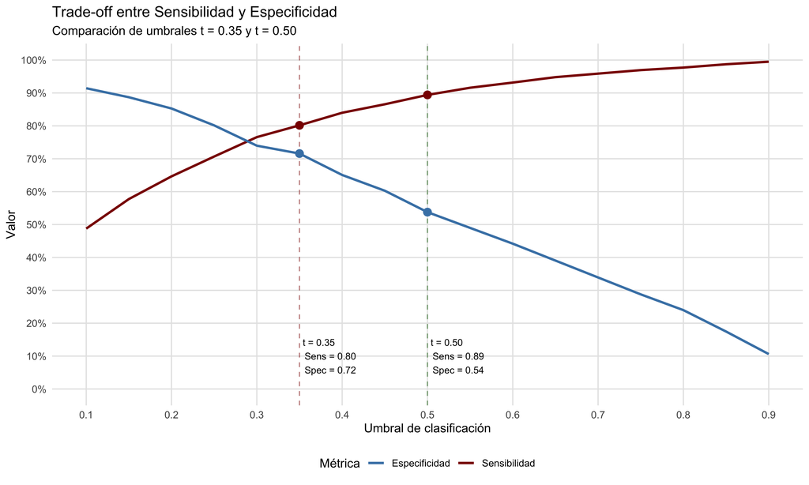

Este análisis sugiere que la pertenencia al 10% superior en Chile está fuertemente estructurada por la combinación de educación y territorio, con la edad jugando un rol moderador. Los errores del modelo iluminan casos donde esta estructura se rompe, sea por rutas alternativas de acceso a altos ingresos (regiones mineras) o por barreras que impiden que el capital educativo se traduzca en retornos económicos equiparables (RM). Además, un dato importante es que parece ser que los pesos disminiyen la specificity considerablemente, probablemente por la subestimación de la RM en la muestra y los falsos negativos y positivos concentrados en esa región.

Las cuatro matrices de confusión presentadas representan diferentes compromisos entre sensibilidad y especificidad, utilizando dos umbrales (0.35 y 0.50) y dos esquemas de ponderación (con y sin pesos).

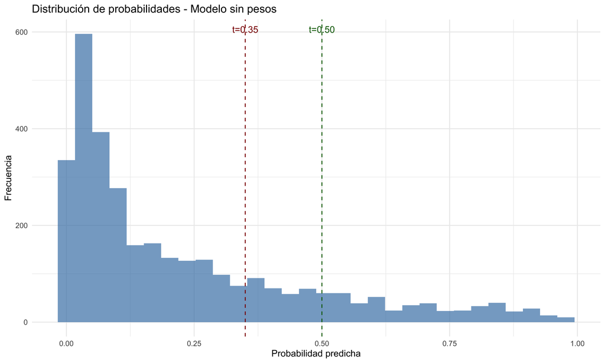

```r
# Dataframe con resultados de los cuatro modelos
results_df <- data.frame(
  actual = test_data$elite,
  pred_unw_05 = predictions_unw_05,
  pred_unw_35 = predictions_unw_35,
  pred_w_05 = predictions_w_05,
  pred_w_35 = predictions_w_35,
  prob_elite_unw = pred_probs_unw[,"Si"],
  prob_elite_w = pred_probs_w[,"Si"],
  region = test_data$region,
  educ_rec = test_data$educ_rec,
  ocupado = test_data$ocupado
)

# Análisis de errores para cada modelo
error_analysis <- results_df %>%
  mutate(
    error_unw_05 = case_when(
      actual == "Si" & pred_unw_05 == "No" ~ "Falso Negativo",
      actual == "No" & pred_unw_05 == "Si" ~ "Falso Positivo",
      TRUE ~ "Correcto"
    ),
    error_unw_35 = case_when(
      actual == "Si" & pred_unw_35 == "No" ~ "Falso Negativo",
      actual == "No" & pred_unw_35 == "Si" ~ "Falso Positivo",
      TRUE ~ "Correcto"
    )
  )

# Visualización de distribución de probabilidades
plot_probs <- function(data, probs, title) {
  ggplot(data, aes(x = probs)) +
    geom_histogram(bins = 30, alpha = 0.7, fill = "steelblue") +
    geom_vline(xintercept = c(0.35, 0.5),
               linetype = "dashed",
               color = c("darkred", "darkgreen")) +
    theme_minimal() +
    labs(
      title = title,
      x = "Probabilidad predicha",
      y = "Frecuencia"
    ) +
    annotate("text", x = 0.35, y = Inf, label = "t=0.35",
             vjust = 2, color = "darkred") +
    annotate("text", x = 0.5, y = Inf, label = "t=0.50",
             vjust = 2, color = "darkgreen")
}

# Gráficos de distribución de probabilidades
p1 <- plot_probs(results_df, results_df$prob_elite_unw, "Distribución de probabilidades - Modelo sin pesos")
p2 <- plot_probs(results_df, results_df$prob_elite_w, "Distribución de probabilidades - Modelo con pesos")

p1
```

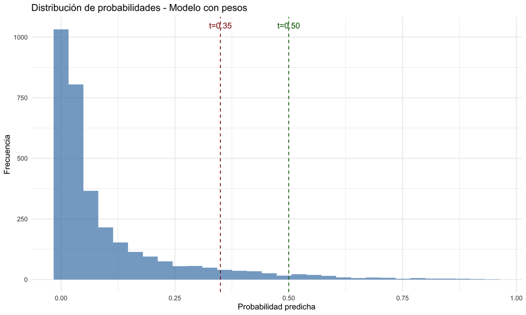

```r
p2
```

## Conclusiones generales:

Los errores del modelo son especialmente reveladores: identifican dos grupos distintos que desafían los patrones típicos. Por un lado, encontramos “falsos positivos” concentrados en la RM - personas con características similares a la elite (especialmente en educación) pero sin los ingresos correspondientes. Por otro lado, los “falsos negativos” se concentran en regiones mineras, sugiriendo rutas alternativas de acceso a altos ingresos que no dependen necesariamente del capital educativo.

## Bibliografía:

Gilens, M. (2012). Affluence and influence: Economic inequality and political power in America. Princeton, NJ: Princeton University Press.

Hernando, M. & Mitchell, G. (2023). Uncomfortably off: Why the Top 10% of Earners Should Care about Inequality. Bristol: Policy Press.

Mac-Clure, O., Barozet, E., & Maturana, V. (2014). Desigualdad, clase media y territorio en Chile: ¿clase media global o múltiples mesocracias según territorios?. Revista EURE - Revista De Estudios Urbano Regionales, 40(121).

Méndez, M.L., & Gayo, M. (2024). The Politics of the Elite: Ideological Orientations, Mothering, and Social Mobilities in Neoliberal Chile. London: Routledge.

Rothman, K. J., & Greenland, S. (2018). Planning Study Size Based on Precision Rather Than Power. Epidemiology, 29(5), 599-603.

van Smeden, M., Moons, K. G., de Groot, J. A., Collins, G. S., Altman, D. G., Eijkemans, M. J., & Reitsma, J. B. (2019). Sample size for binary logistic prediction models: Beyond events per variable criteria. Statistical Methods in Medical Research, 28(8), 2455-2474.

Wilkinson, R. & Pickett, K. (2010). The spirit level: Why equality is better for everyone. London: Penguin.

Wilkinson, R. & Pickett, K. (2019). The inner level: How more equal societies reduce stress, restore sanity and improve everyone’s well-being. London: Penguin.